# R Code for Chapter 7 of Introduction to Data Mining: Clustering Analysis

# External Cluster Validation

External cluster validation uses ground truth information. That is, the user has an idea how the data should be grouped. This could be a known class label not provided to the clustering algorithm.

We use an artificial data set with known groups.

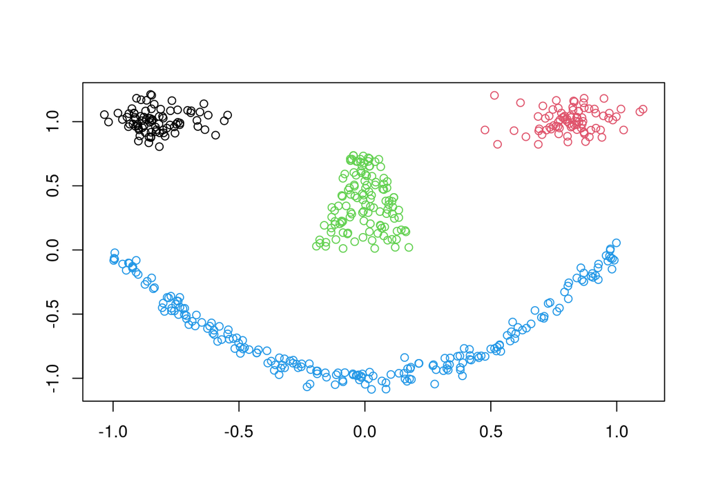

```r
library(mlbench)
set.seed(1234)
shapes <- mlbench.smiley(n = 500, sd1 = 0.1, sd2 = 0.05)
plot(shapes)
```

Prepare data

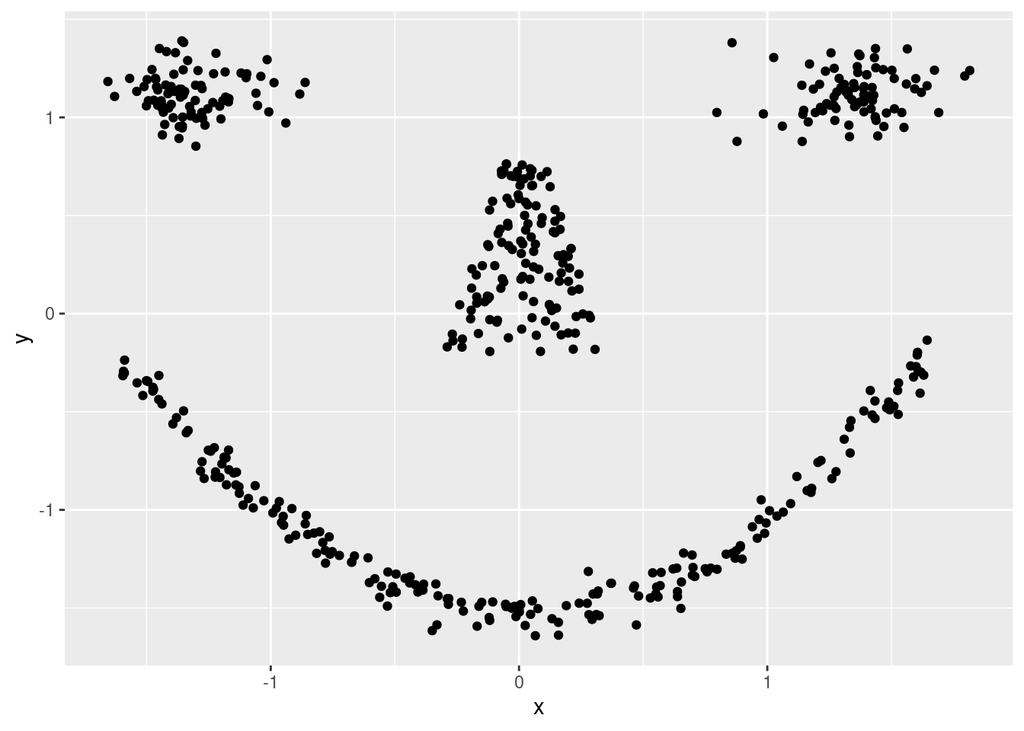

```r
truth <- as.integer(shapes$class)
shapes <- scale(shapes$x)
colnames(shapes) <- c("x", "y")
shapes <- as_tibble(shapes)

ggplot(shapes, aes(x, y)) + geom_point()
```

Find optimal number of Clusters for k-means

```r
ks <- 2:20
```

Use within sum of squares (look for the knee)

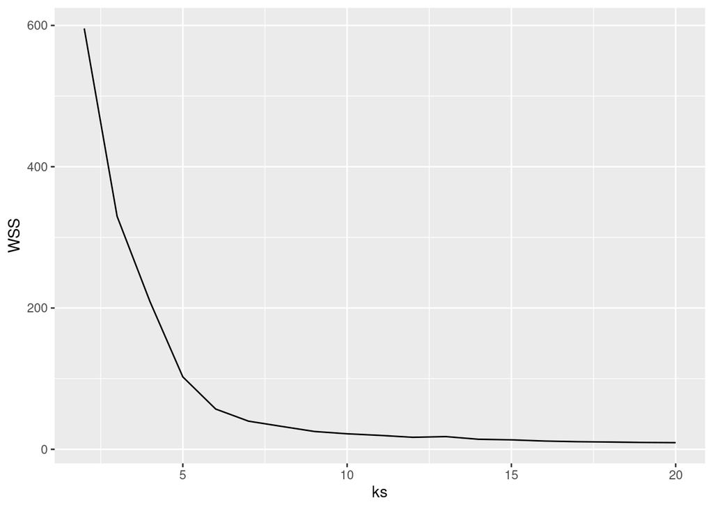

```r
WSS <- sapply(ks, FUN = function(k) {
  kmeans(shapes, centers = k, nstart = 10)$tot.withinss
})

ggplot(as_tibble(ks, WSS), aes(ks, WSS)) + geom_line()
```

Looks like it could be 7 clusters

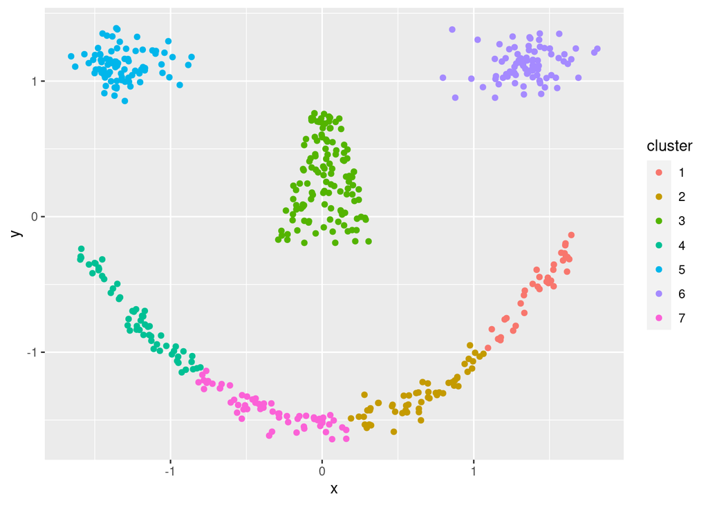

```r
km <- kmeans(shapes, centers = 7, nstart = 10)
ggplot(shapes %>% add_column(cluster = factor(km$cluster)), aes(x, y, color = cluster)) +
  geom_point()
```

Hierarchical clustering: We use single-link because of the mouth is non-convex and chaining may help.

```r
d <- dist(shapes)
hc <- hclust(d, method = "single")
```

Find optimal number of clusters

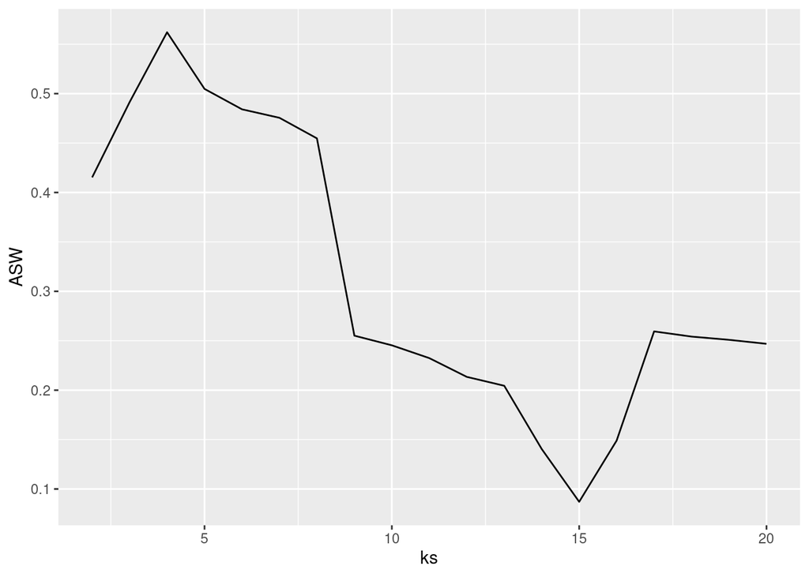

```r
ASW <- sapply(ks, FUN = function(k) {
  fpc::cluster.stats(d, cutree(hc, k))$avg.silwidth
})

ggplot(as_tibble(ks, ASW), aes(ks, ASW)) + geom_line()
```

The maximum is clearly at 4 clusters.

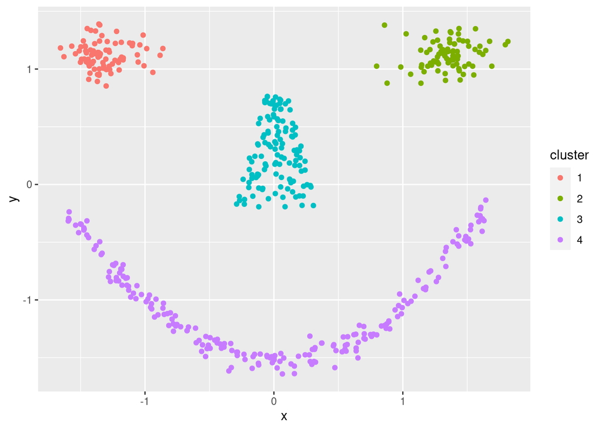

```r
hc_4 <- cutree(hc, 4)
ggplot(shapes %>% add_column(cluster = factor(hc_4)), aes(x, y, color = cluster)) +
  geom_point()
```

Compare with ground truth with the [corrected (=adjusted) Rand index (ARI)](https://en.wikipedia.org/wiki/Rand_index#Adjusted_Rand_index), the [variation of information (VI) index](https://en.wikipedia.org/wiki/Variation_of_information), entropy and purity.

`cluster_stats` computes ARI and VI as comparative measures. I define functions for entropy and purity here:

```r
entropy <- function(cluster, truth) {
  k <- max(cluster, truth)
  cluster <- factor(cluster, levels = 1:k)
  truth <- factor(truth, levels = 1:k)
  w <- table(cluster)/length(cluster)

  cnts <- sapply(split(truth, cluster), table)
  p <- sweep(cnts, 1, rowSums(cnts), "/")
  p[is.nan(p)] <- 0
  e <- -p * log(p, 2)

  sum(w * rowSums(e, na.rm = TRUE))
}

purity <- function(cluster, truth) {
  k <- max(cluster, truth)
  cluster <- factor(cluster, levels = 1:k)
  truth <- factor(truth, levels = 1:k)
  w <- table(cluster)/length(cluster)

  cnts <- sapply(split(truth, cluster), table)
  p <- sweep(cnts, 1, rowSums(cnts), "/")
  p[is.nan(p)] <- 0

  sum(w * apply(p, 1, max))
}
```

calculate measures (for comparison we also use random “clusterings” with 4 and 6 clusters)

```r
random_4 <- sample(1:4, nrow(shapes), replace = TRUE)
random_6 <- sample(1:6, nrow(shapes), replace = TRUE)

r <- rbind(
  kmeans_7 = c(
    unlist(fpc::cluster.stats(d, km$cluster, truth, compareonly = TRUE)),
    entropy = entropy(km$cluster, truth),
    purity = purity(km$cluster, truth)
    ),
  hc_4 = c(
    unlist(fpc::cluster.stats(d, hc_4, truth, compareonly = TRUE)),
    entropy = entropy(hc_4, truth),
    purity = purity(hc_4, truth)
    ),
  random_4 = c(
    unlist(fpc::cluster.stats(d, random_4, truth, compareonly = TRUE)),
    entropy = entropy(random_4, truth),
    purity = purity(random_4, truth)
    ),
  random_6 = c(
    unlist(fpc::cluster.stats(d, random_6, truth, compareonly = TRUE)),
    entropy = entropy(random_6, truth),
    purity = purity(random_6, truth)
    )
  )
r
```

```
##          corrected.rand        vi   entropy    purity
## kmeans_7    0.638228776 0.5708767 0.2285591 0.4638565
## hc_4        1.000000000 0.0000000 0.0000000 1.0000000
## random_4   -0.003235188 2.6831737 1.9883398 0.2878286
## random_6   -0.002125389 3.0762751 1.7280983 0.1436265
```

Notes:

- Hierarchical clustering found the perfect clustering.
- Entropy and purity are heavily impacted by the number of clusters (more clusters improve the metric).
- The corrected rand index shows clearly that the random clusterings have no relationship with the ground truth (very close to 0). This is a very helpful property.

Read `? cluster.stats` for an explanation of all the available indices.

# Related Topics

## Outlier Removal

Most clustering algorithms perform complete assignment (i.e., all data points need to be assigned to a cluster). Outliers will affect the clustering. It is useful to identify outliers and remove strong outliers prior to clustering. A density based method to identify outlier is [LOF](https://en.wikipedia.org/wiki/Local_outlier_factor) (Local Outlier Factor). It is related to dbscan and compares the density around a point with the densities around its neighbors (you have to specify the neighborhood size $k$). The LOF value for a regular data point is 1. The larger the LOF value gets, the more likely the point is an outlier.

```r
library(dbscan)
```

Add a clear outlier to the scaled Ruspini dataset

```r
ruspini_scaled_outlier <- ruspini_scaled %>% add_case(x=10,y=10)
```

Outliers can be identified using summary statistics, histograms, scatterplots (pairs plots), and boxplots, etc. We use here a pairs plot (the diagonal contains smoothed histograms). The outlier is visible as the single point at (10, 10) in the scatter plot and as the long tail of the smoothed histograms.

```r
library("GGally")
```

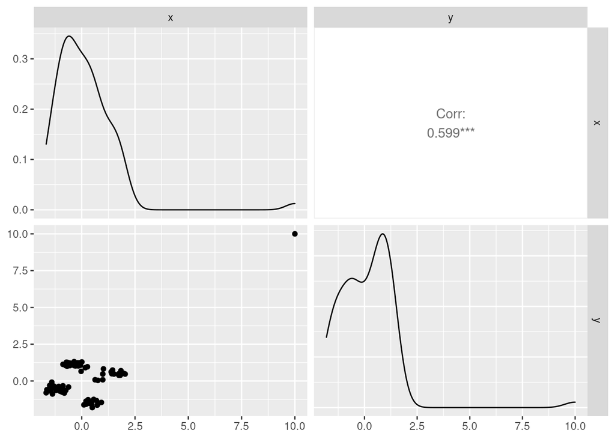

```r
ggpairs(ruspini_scaled_outlier)
```

The outlier is a problem for k-means

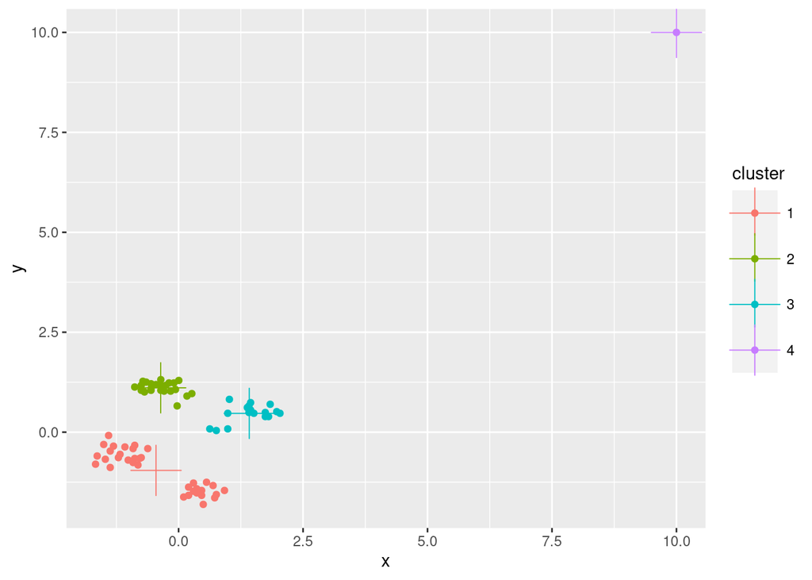

```r
km <- kmeans(ruspini_scaled_outlier, centers = 4, nstart = 10)
ruspini_scaled_outlier_km <- ruspini_scaled_outlier%>%
  add_column(cluster = factor(km$cluster))
centroids <- as_tibble(km$centers, rownames = "cluster")

ggplot(ruspini_scaled_outlier_km, aes(x = x, y = y, color = cluster)) + geom_point() +
  geom_point(data = centroids, aes(x = x, y = y, color = cluster), shape = 3, size = 10)
```

This problem can be fixed by increasing the number of clusters and removing small clusters in a post-processing step or by identifying and removing outliers before clustering. We will use the Local Outlier Facto to identify and remove potential outliers. Calculate the LOF (I choose a neighborhood size of 10 for density estimation),

```r
lof <- lof(ruspini_scaled_outlier, k = 10)
lof
```

```
##  [1]  1.0301445  1.4702042  1.0443560  1.1837238  0.9768875  0.9699829
##  [7]  1.0001116  1.1535510  0.9960937  1.0905863  0.9663995  1.0454183
## [13]  0.9675956  0.9544677  0.9337237  0.9894256  0.9884217  1.0075225
## [19]  0.9843103  1.2364259  1.0287440  1.0713052  1.1812173  0.9908331
## [25]  1.0823889  1.0024981  1.3782183  1.3261349  0.9263148  0.9114424
## [31]  0.9641881  1.0744475  1.0000393  1.0829739  1.1073351  1.0216684
## [37]  0.9663276  0.9889136  1.1235962  1.0309614  1.0706786  0.9975426
## [43]  0.9518995  1.0219661  1.0453126  1.0289861  1.0664962  0.9415955
## [49]  1.0084704  1.0237475  0.9583990  1.0194008  0.9867823  1.1524336
## [55]  1.1742991  0.9980409  1.0093201  1.5239782  0.9839311  1.1162943
## [61]  1.5659319  1.0577039  1.5882842  1.0279401  0.9778143  1.0010129
## [67]  0.9789993  1.0798250  0.9787700  1.0180003  0.9730739  1.0464727
## [73]  1.2008933  0.9337237  0.9328888 25.4497784
```

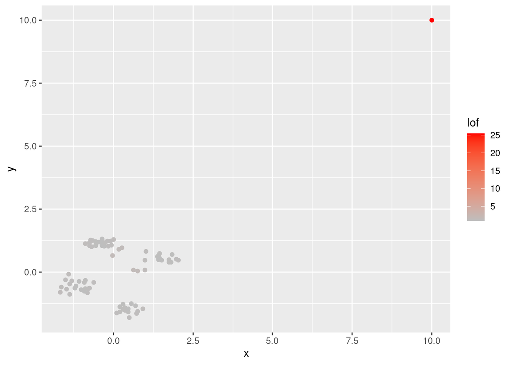

```r
ggplot(ruspini_scaled_outlier %>% add_column(lof = lof), aes(x, y, color = lof)) +
    geom_point() + scale_color_gradient(low = "gray", high = "red")
```

Plot the points sorted by increasing LOF.

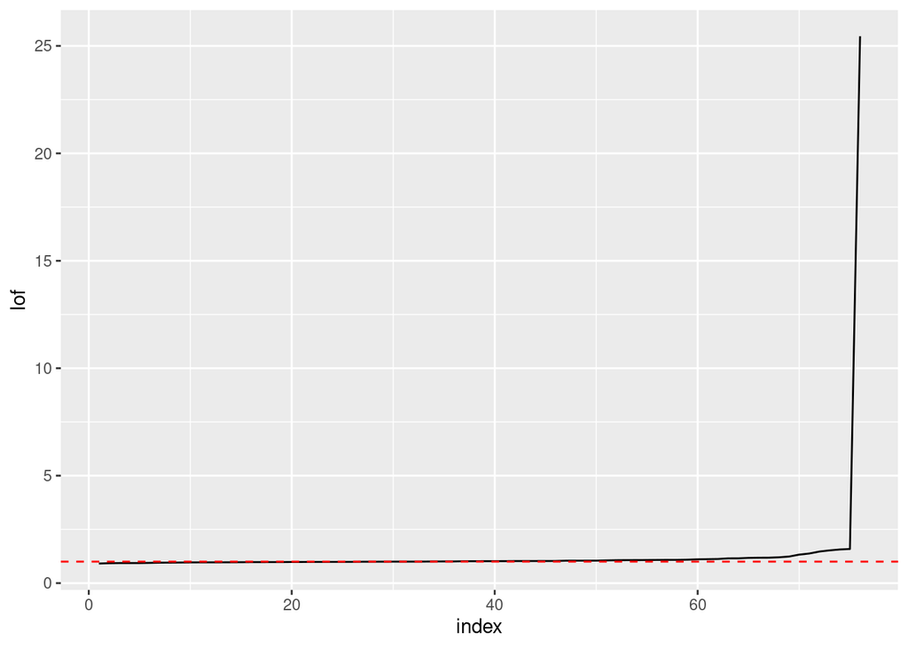

```r
ggplot(tibble(index = seq_len(length(lof)), lof = sort(lof)), aes(index, lof)) +
  geom_line() +
  geom_hline(yintercept = 1, color = "red", linetype = 2)
```

Choose a threshold above 1.

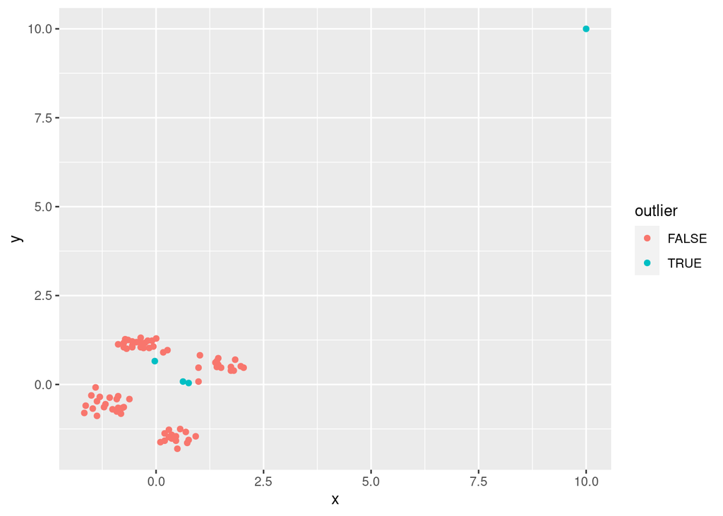

```r
ggplot(ruspini_scaled_outlier %>% add_column(outlier = lof >= 1.5), aes(x, y, color = outlier)) +
  geom_point()
```

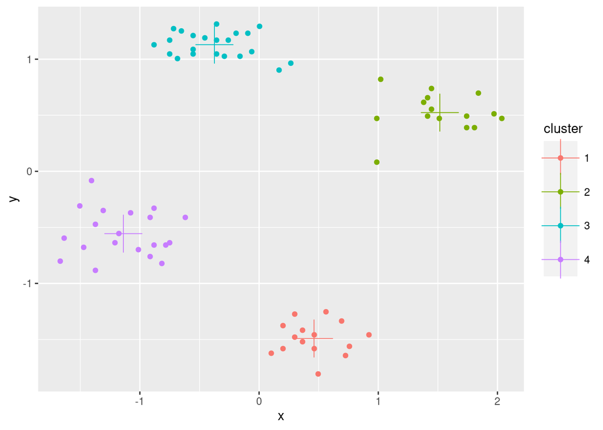

```r
# Remove outliers and cluster.
ruspini_scaled_clean <- ruspini_scaled_outlier  %>% filter(lof < 1.5)

km <- kmeans(ruspini_scaled_clean, centers = 4, nstart = 10)
ruspini_scaled_clean_km <- ruspini_scaled_clean%>%
  add_column(cluster = factor(km$cluster))
centroids <- as_tibble(km$centers, rownames = "cluster")

ggplot(ruspini_scaled_clean_km, aes(x = x, y = y, color = cluster)) + geom_point() +
  geom_point(data = centroids, aes(x = x, y = y, color = cluster), shape = 3, size = 10)
```

There are many other outlier removal strategies available. See, e.g., package outliers.

## Clustering Tendency

Most clustering algorithms will always produce a clustering, even if the data does not contain a cluster structure. It is typically good to check cluster tendency before attempting to cluster the data.

We use again the smiley data.

```r
library(mlbench)
shapes <- mlbench.smiley(n = 500, sd1 = 0.1, sd2 = 0.05)$x
colnames(shapes) <- c("x", "y")
shapes <- as_tibble(shapes)
```

The first step is visual inspection using scatter plots.

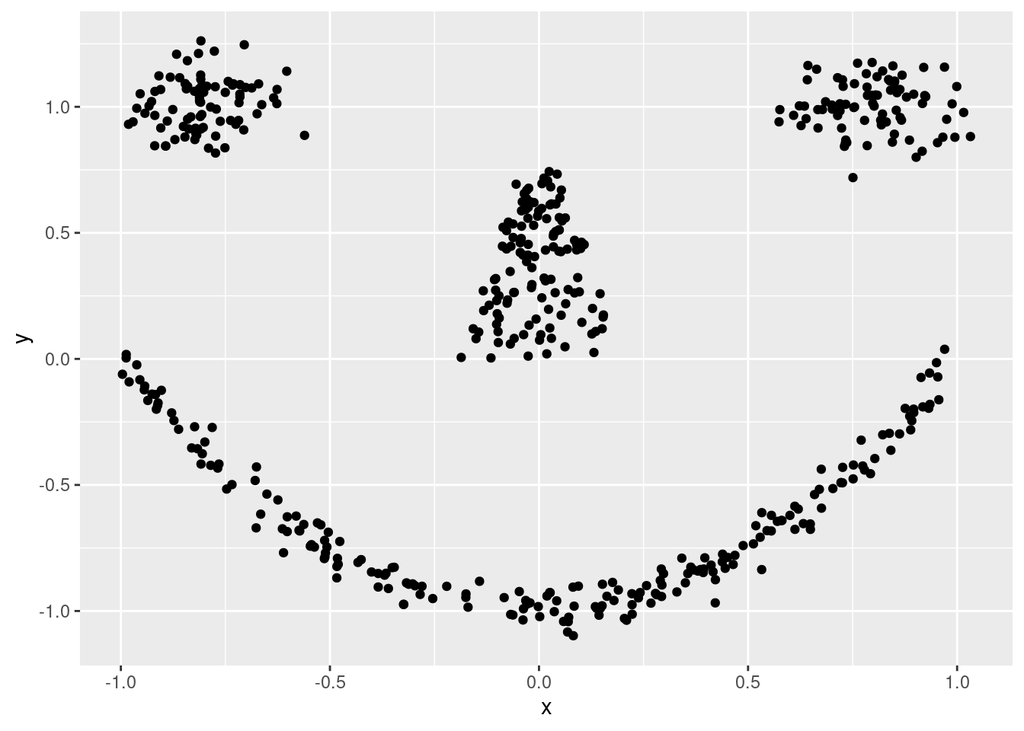

```r
ggplot(shapes, aes(x = x, y = y)) + geom_point()
```

Cluster tendency is typically indicated by several separated point clouds. Often an appropriate number of clusters can also be visually obtained by counting the number of point clouds. We see four clusters, but the mouth is not convex/spherical and thus will pose a problems to algorithms like k-means.

If the data has more than two features then you can use a pairs plot (scatterplot matrix) or look at a scatterplot of the first two principal components using PCA.

```r
library(seriation)
```

Visual Analysis for Cluster Tendency Assessment (VAT) reorders the objects to show potential clustering tendency as a block structure (dark blocks along the main diagonal). We scale the data before using Euclidean distance.

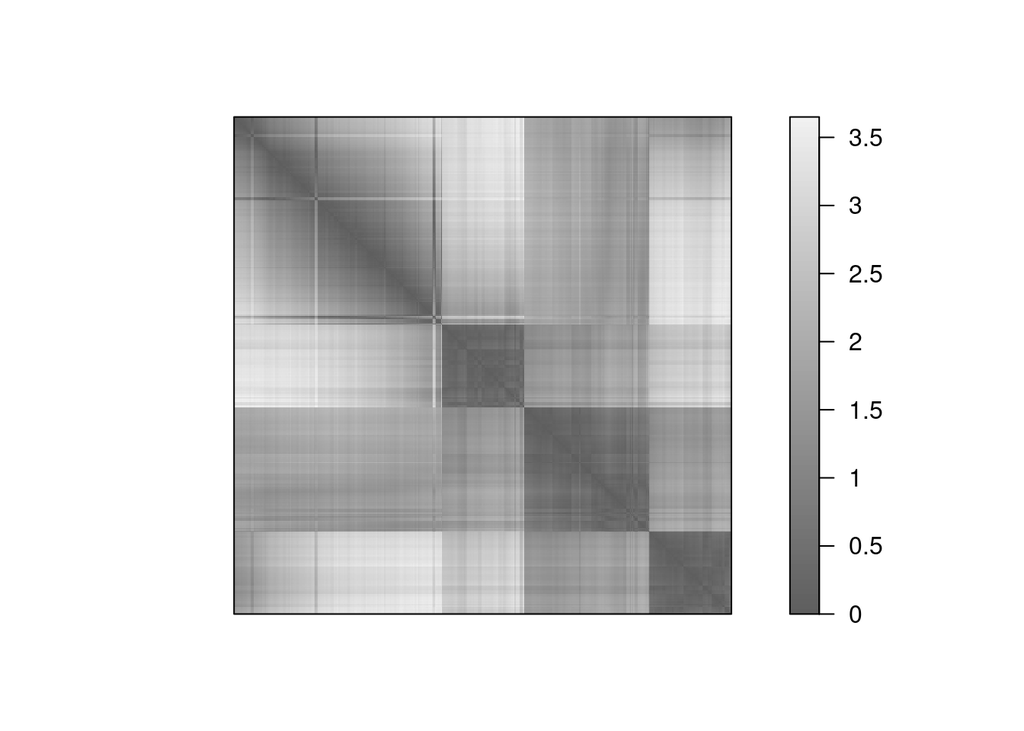

```r
d_shapes <- dist(scale(shapes))
VAT(d_shapes)
```

iVAT uses the largest distances for all possible paths between two objects instead of the direct distances to make the block structure better visible.

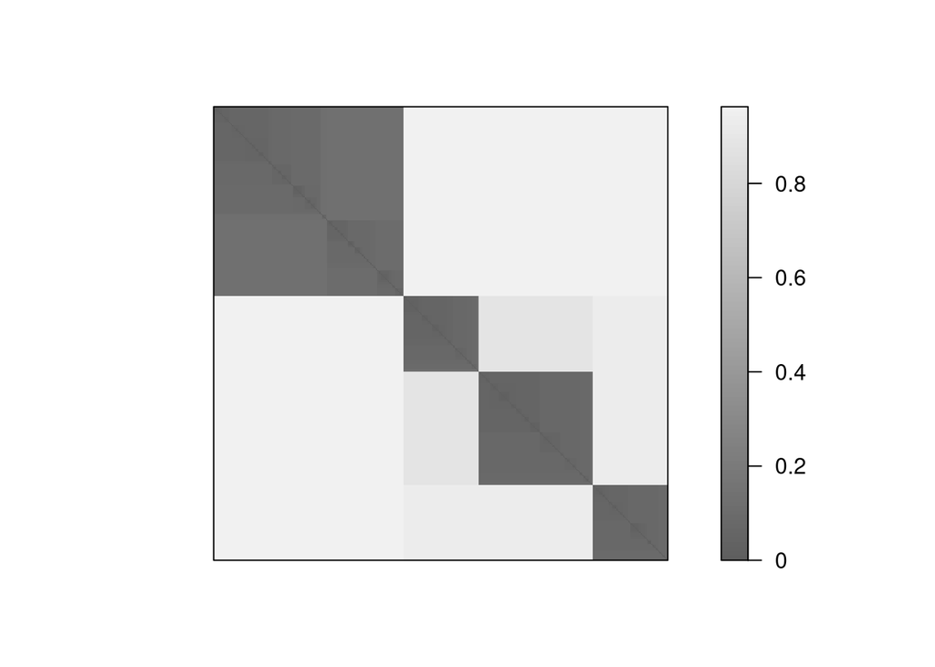

```r
iVAT(d_shapes)
```

Both plots show a strong cluster structure with 4 clusters.

### Data Without Clustering Tendency

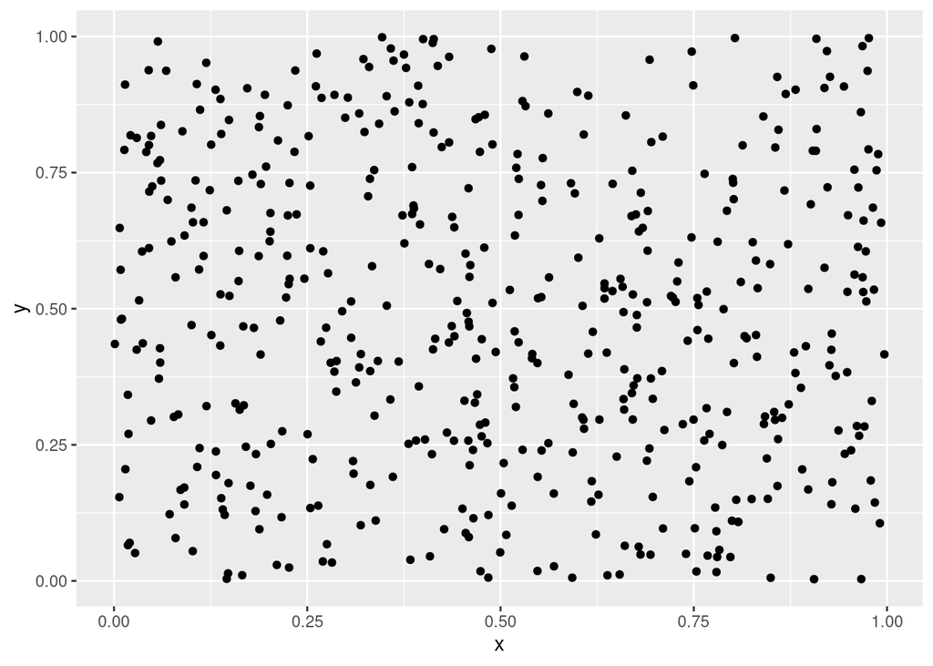

```r
data_random <- tibble(x = runif(500), y = runif(500))
ggplot(data_random, aes(x, y)) + geom_point()
```

No point clouds are visible, just noise.

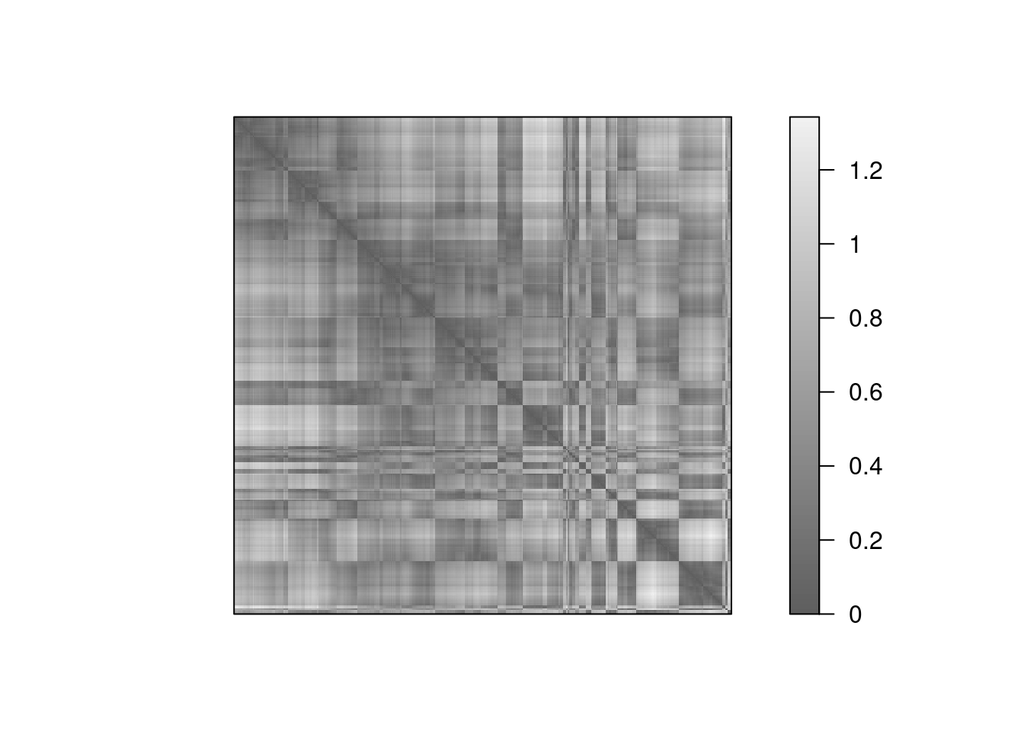

```r
d_random <- dist(data_random)
VAT(d_random)
```

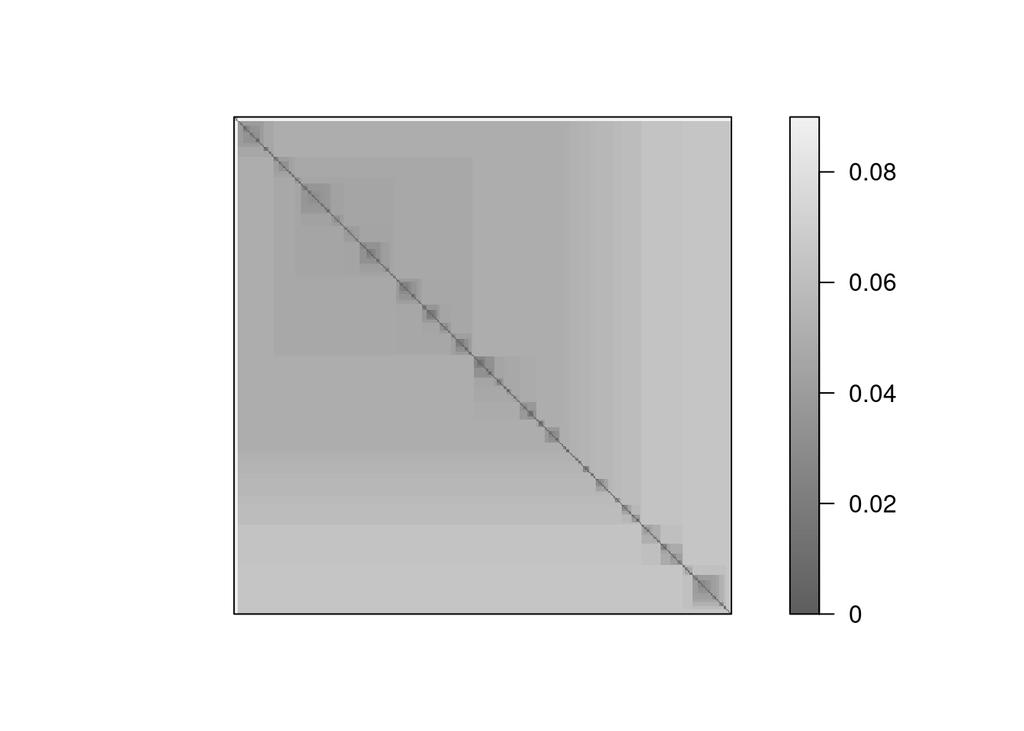

```r
iVAT(d_random)
```

There is very little clustering structure visible indicating low clustering tendency and clustering should not be performed on this data. However, k-means can be used to partition the data into $k$ regions of roughly equivalent size. This can be used as a data-driven discretization of the space.

### k-means on Data Without Clustering Tendency

What happens if we perform k-means on data that has no inherent clustering structure?

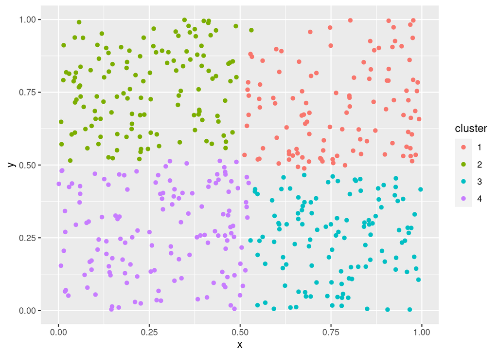

```r
km <- kmeans(data_random, centers = 4)
random_clustered<- data_random %>% add_column(cluster = factor(km$cluster))
ggplot(random_clustered, aes(x = x, y = y, color = cluster)) + geom_point()
```

k-means discretizes the space into similarly sized regions.